# CovidNet Dataset Exploration

Lio

07/05/2020

## CoronaNet Dataset

The CoronaNet dataset records government responses to the Covid-19 pandemic and underlies the paper ‘A Retrospective Bayesian Model for Measuring Covariate Effects on Observed Covid-19 Test and Case Counts’ by Cheng et al. (2020). The dataset, paper and all related files and code can be found at https://github.com/saudiwin/corona_tscs.

The dataset is fairly complex, as it covers more than 140 countries and contains about 14,000 government actions since January 2020. In its raw form, it is at the country-day-action level, with several dimensions that characterise each government action. This document seeks to improve the understanding of the dataset in a rather descriptive way, and ultimately to bring it into a form that lends itself to further analysis regarding behavioural factors that influence political response and / or epidemiology of Covid-19.

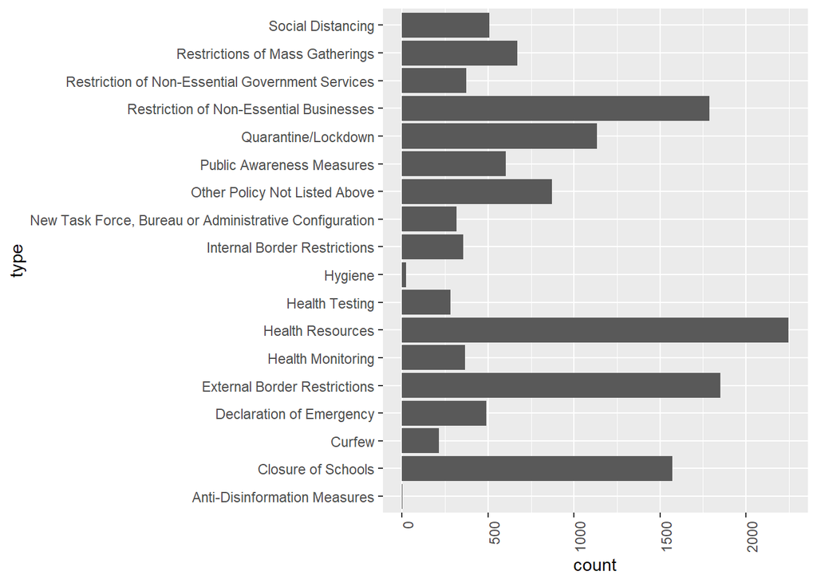

Each of these types of events is divided into sub-types. Below are breakdowns of the most frequent categories.

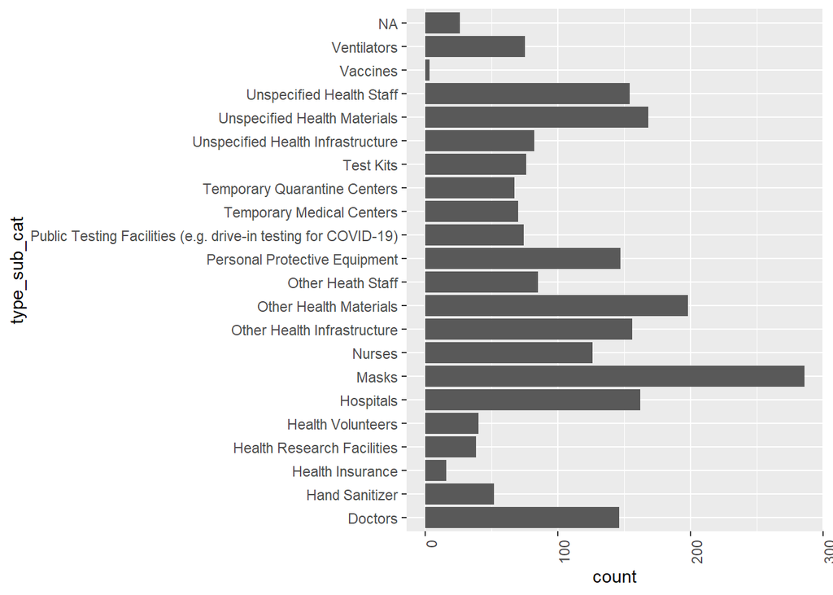

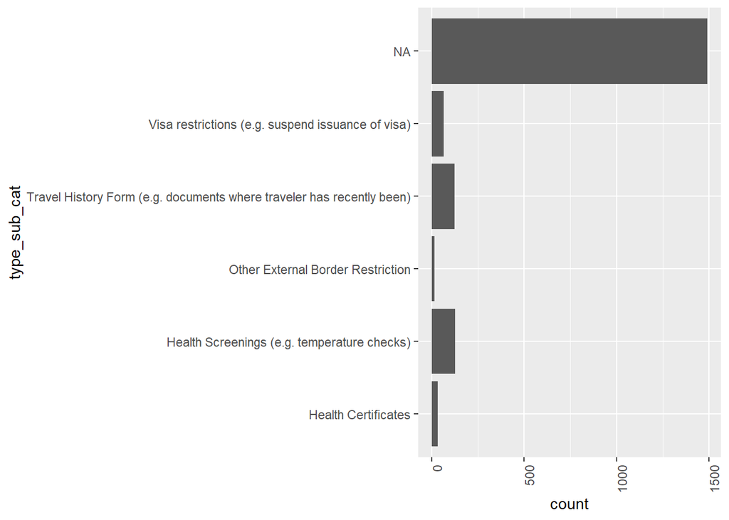

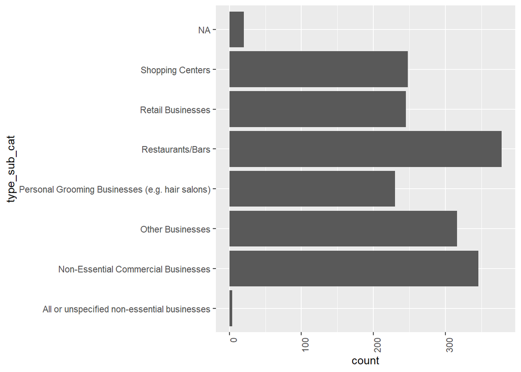

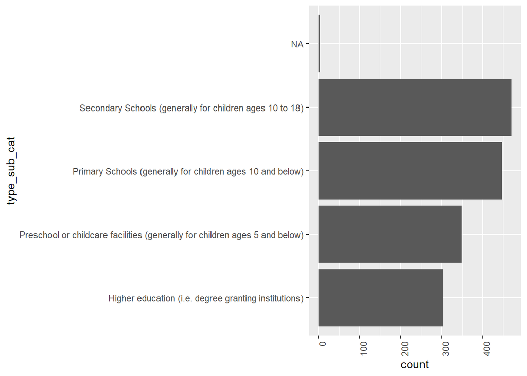

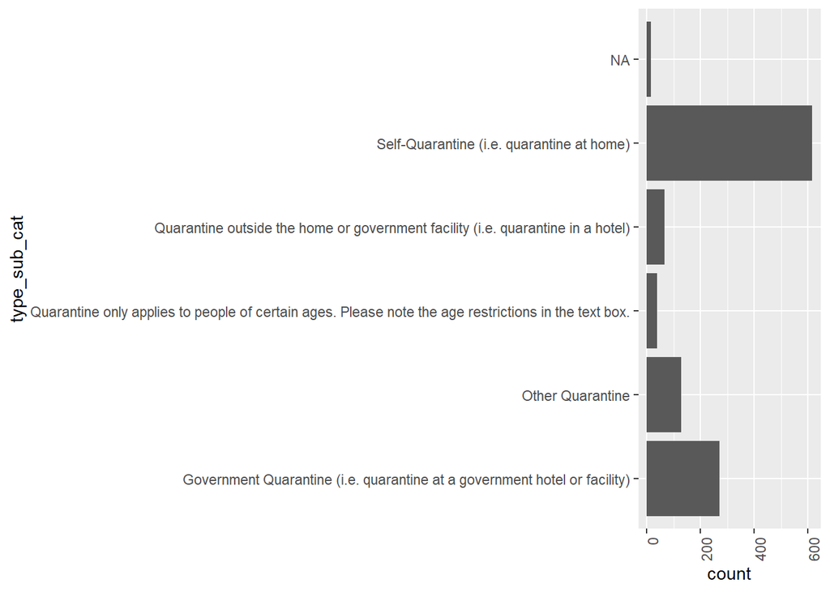

The reports further details about each measure; a potentially important one is whether measures are mandatory or voluntary. Let’s have a look for quarantine/lockdowns (note that there are a bunch of categories, I simplify it to mandatory and voluntary):

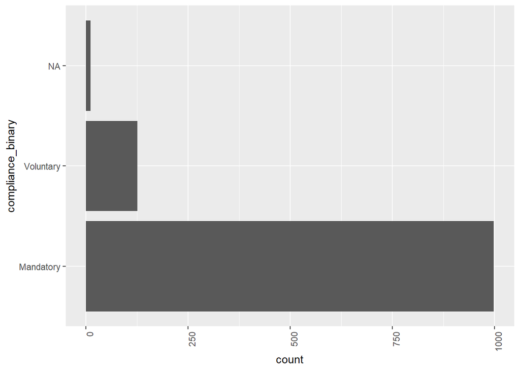

There are something like 1000 mandatory lockdowns measures recorded, obviously this doesn’t exactly coincide with what we normally consider ‘the’ lockdown (of which you wouldn’t expect more than one per country), so the first challenge is to identify what constitutes a “proper” lockdown.

## Lockdowns by country

A first piece of the puzzle may lie in the distribution of lockdowns measures by country (only 40 countries with the highest number of lockdown measures included in the plot for readability):

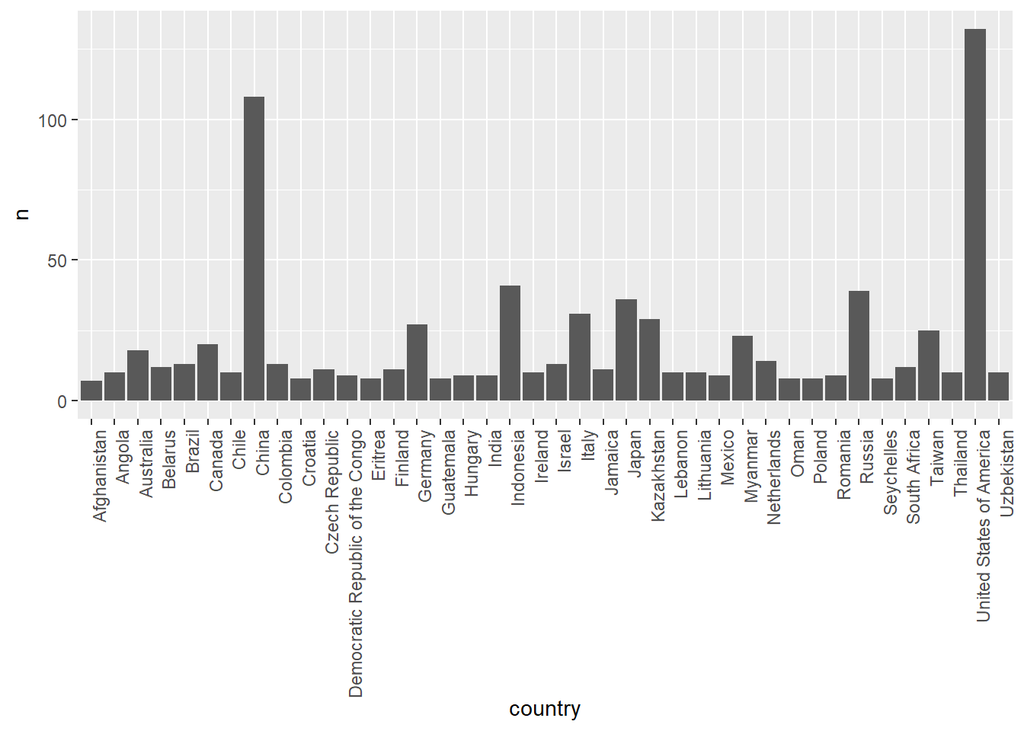

China and the US stick out, I suspect substantial reporting bias. The large number of actions isn’t surprising in the federal US however, and in general federalist states will be a bit of a challenge in the analysis / aggregation of the data. Plotted below is the administrative level at which lockdowns / lockdown measures are recorded (globally):

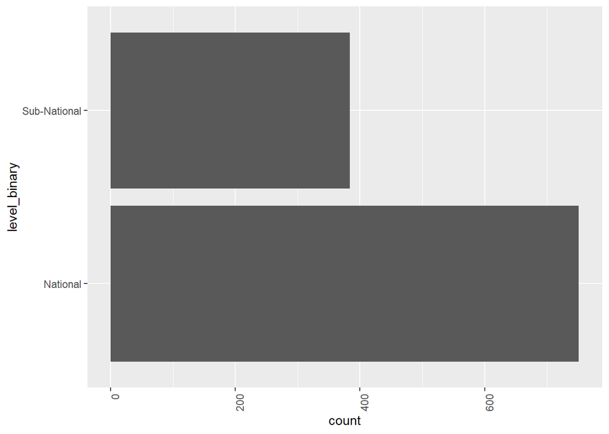

## Lockdowns over time

Let us also look at when those lockdown measures came into place.

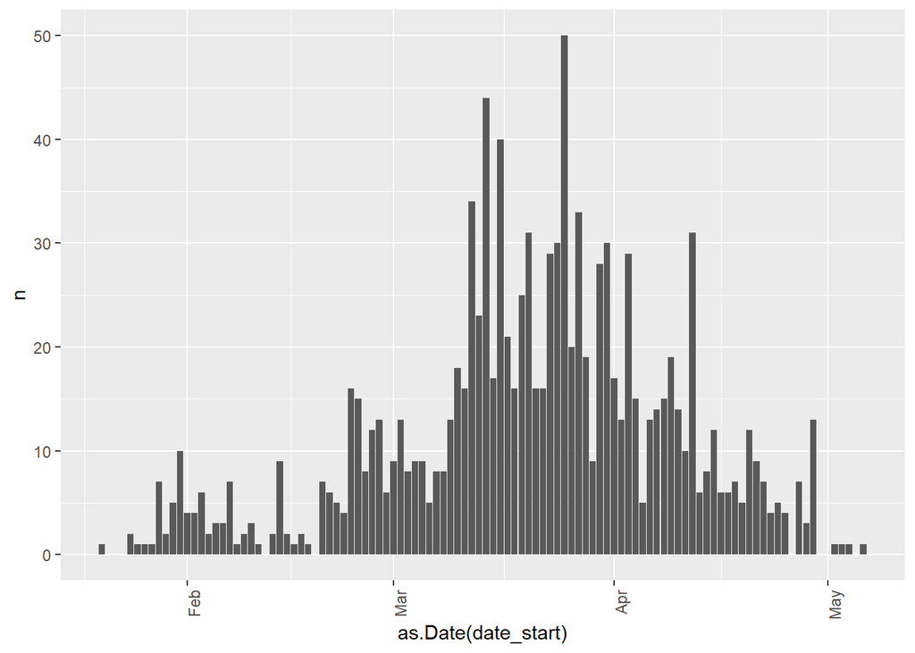

As expected, there is a bunching around mid- to end-March.

## Policy Activity Index

Cheng et al. (2020) also construct a ‘Policy Activity Index’ - I am not entirely sure how this is constructed yet and what it is meant to measure. Here is what it looks like:

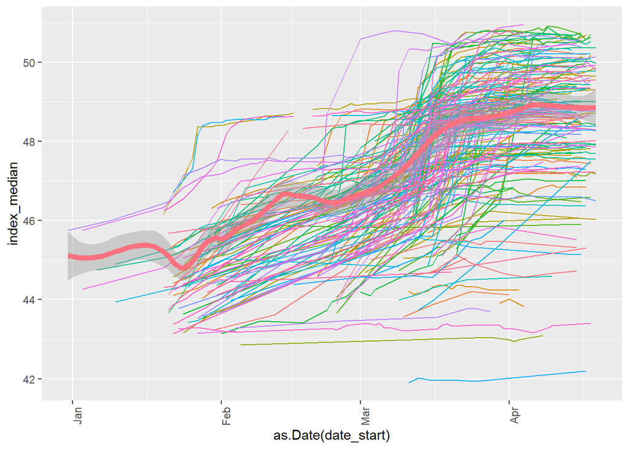

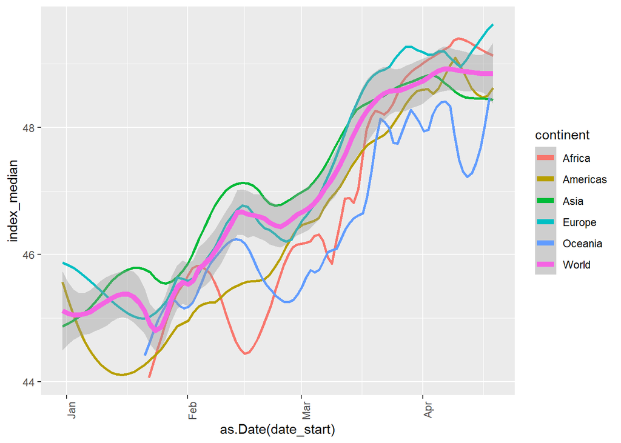

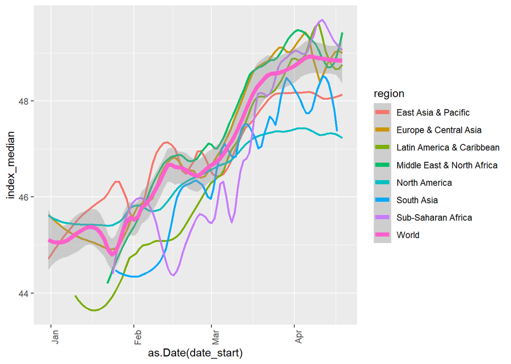

## Identifying lockdown dates

In order to identify the dates of what we would call a lockdown, I pick the first date a measure came into effect that is categorised as (i) Quarantine / Lockdown and (ii) Mandatory.

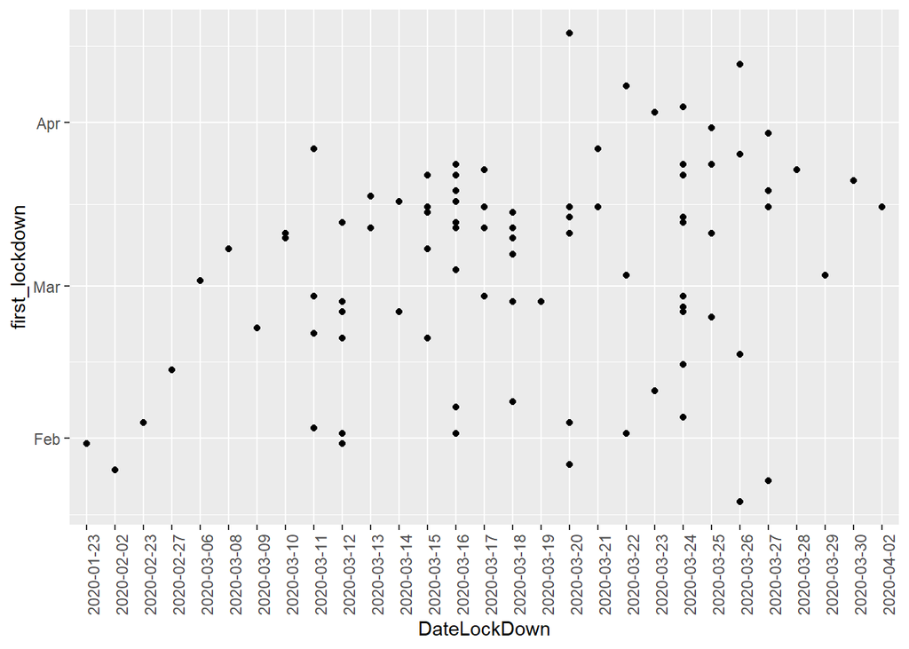

Plotting those against our originally recorded lockdown dates creates a real mess, so clearly this needs some kind of reconciliation (the same exercise filtering only for nation-wide lockdowns yields the same).

## Policy activity index and movement

Below is a plot of the Cheng Policy Activity Index and Movement (Google) for a few selected countries.

The definition of the index is a little vague, the researchers don’t seem comfortable providing any straightforward explanation as to what it represents. The main criterion seems to be the ‘costliness’ of any given policy for a givernment:

> Given the enormous size of our data, we constructed a policy activity index that summarizes the different indicators in our data for each country for each day since Dec 31st 2019. The index is produced using a statistical model that takes into account which policies seem to be more costly/difficult to implement than other policies. For more details on the methodology, see our working paper. [https://coronanet-project.org/visuals.html]

The working paper does’t offer much of a clarification (but it does show parameters, like the relative weight of different measures); my main concerns are:

- Is ‘cost’ confounded with ‘usefulness’? I’m not sure whether a policy is considered costly because it is implemented late or only briefly, or because perhaps the coder had to rate it. If the former is the case, the policy may well have been implemented late / removed early because it just isn’t that effective in containing the spread of the virus.
- They seem to aim at making ‘policy activity’ or ‘severity’ (they seem to have switched to that latter expression in recent releases) comparable across countries, that is, absolute values of the index meaningful. While I wouldn’t discard that altogether, it probably is very much undermined by data reporting issues.

In any case, as expected, movement and this index tend to move in opposite directions although the pattern isn’t too clear cut.

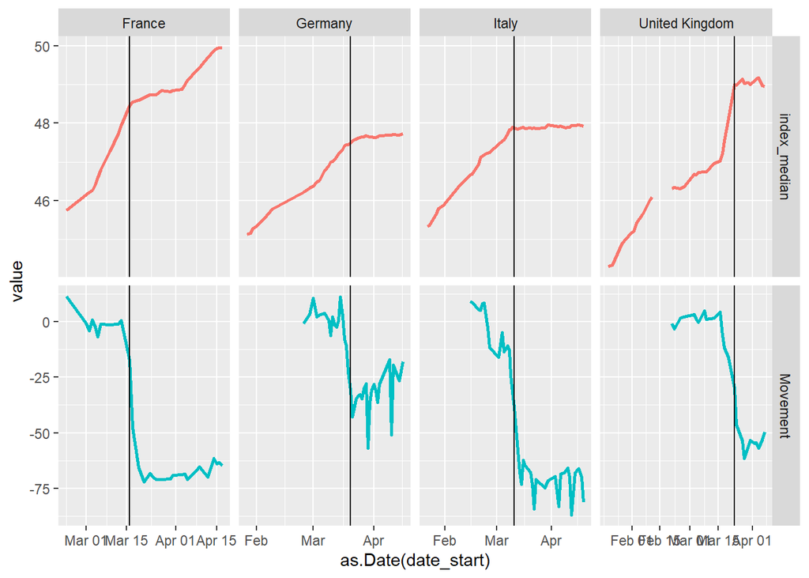

## Next steps

- Code most relevant events into country-day format (decide what’s relevant)
- Merge with existing dataset
- Explore time series analysis / macro panel options with complete dataset